# Customizing Plots

Kyle Baron

2022-05-13

# Set up

```r
library(pmplots)
library(dplyr)

data <- pmplots_data_obs()
```

# A default plot

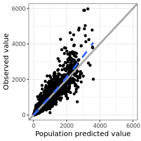

```r
dv_pred(data)
```

## Customize the axis label

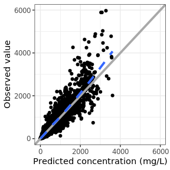

```r
dv_pred(data) + labs(x = "Predicted concentration (mg/L)")
```

## Add Greek symbols to an axis label

There are a couple of ways to do this. The easiest is to have the latex2exp package installed and write the TeX right in the label.

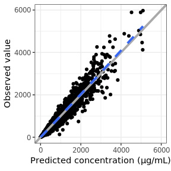

```r
dv_pred(data, x = "IPRED//Predicted concentration ($\\mu$g/mL)")
```

Otherwise, you can trigger R plotmath by putting `!!` at the start of the column label

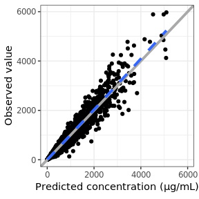

```r
dv_pred(data, x = "IPRED//!!'Predicted concentration (' * mu * 'g/mL)'")
```

## Add a run number or other annotation to the plot

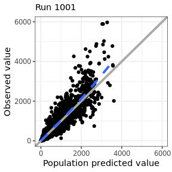

```r
dv_pred(data) + labs(subtitle = "Run 1001")
```

# Adopt the pmplots look and feel

At some point, you might have to create a plot outside of pmplots, but you still want to adopt the pmplots look and feel.

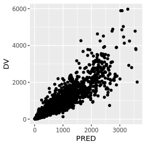

```r
p <- ggplot(data = data, aes(PRED,DV)) + geom_point()
p
```

Use these helpers to style the plot

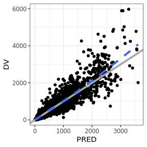

```r
p + pm_theme() + pm_abline() + pm_smooth()
```

# Customize the axis

If you start with this plot

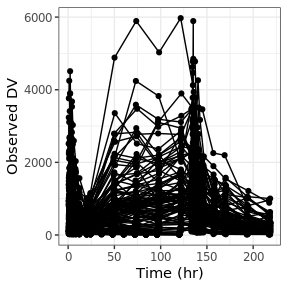

```r
dv_time(data)
```

you can use the `xs` and `ys` arguments to customize the x or y axis. Pass a list of named data that corresponds to arguments that you would pass to `ggplot2::scale_x_continuous()` or `ggplot2::scale_y_continuous()`. For example we can set the breaks like this

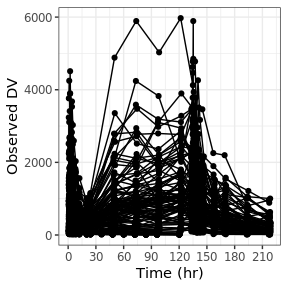

```r
dv_time(data, xs = list(breaks = seq(0,240,30)))
```

But note there is an easier way using `xby` argument for any of the `*_time()` plots

```r
dv_time(data, xby = 30)
```

You can put the y-axis on log scale

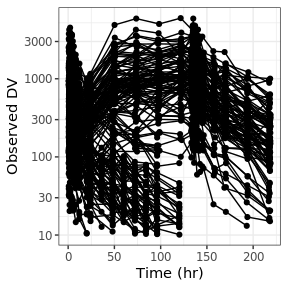

```r
dv_time(data, ys = list(trans = "log10"))
```

Again note there is a `log` argument to this function that lets us do this more conveniently

```r
dv_time(data, log = TRUE)
```

While we’ve had some convenient shortcuts built into some of the functions, this should illustrate how you can control anything related to the axis scales in your plot.

Specifically not that you should not do this

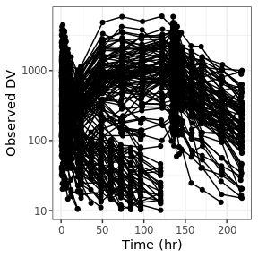

```r
dv_time(data) + scale_y_continuous(trans = "log10")
```

This will result in a warning and clobber the scale that pmplots set. Always customize the axis through `xs` and `ys`.

# Rotate axis labels

Use `rot_x()` or `rot_y()` and specify the angle to rotate the tick labels

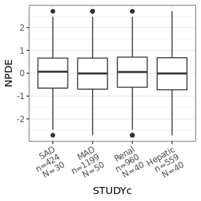

```r
cont_cat(data, x = "STUDYc", y = "NPDE") + rot_x(30)
```

or just set `vertical = TRUE` for `rot_x()`

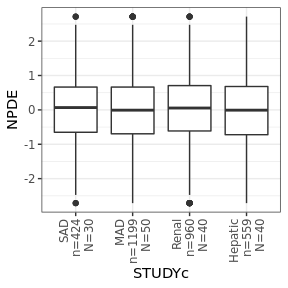

```r
cont_cat(data, x = "STUDYc", y = "NPDE") +
  rot_x(vertical = TRUE)
```